# Intro to ggplot2

Ted Laderas

March 11, 2015

# Intro to Hadleyland

Hadley Wickham started building solutions to specific R problems as part of his dissertation work, expanding to form an empire within R.

- plyr/dplyr (How do I apply functions to different data structures?)
- reshape2 (How can I change/summarize data from one form to another)
- ggplot2 (How can I make pretty graphics?)
- testthat (Unit testing framework for R)

# The Grammar of Graphics

ggplot2 is a graphical plotting package that utilizes a “grammar of graphics”:

```r
ggplot(iris) + geom_point(aes(x = Sepal.Length, y = Sepal.Width))

# + theme_minimal()
```

- Specify data with ggplot()
- Specify data representation with geoms (layer)
  - (bar, line, scatter, heatmap, etc)
- Specify data mapping with aes()
  - (x, y, Color, Size, fill)
- Subset data with facets
- Change the look around with themes
- Add other properties (titles, etc)

# Simple Example

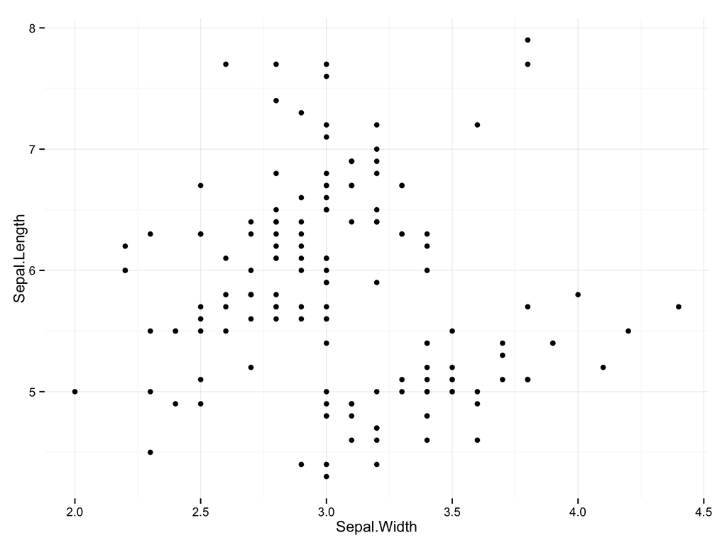

```r
library(ggplot2)
data(iris)
ggplot(iris) + geom_point(aes(x= Sepal.Width, y=Sepal.Length)) + theme_minimal()
```

# aes() - the Aesthetic Function

aes() lets you map a variable to a visual property of the geom. Aesthetics can include:

- x or y (almost any geom)
- size
- color (point or line)
- shape (point)
- linetype (line)
- fill (rect, bar, histogram)

Documentation for aes() is remarkably terrible, as it’s different for each geom. Look at the documentation for each geom for a list of mappable aesthetics.

# Let’s get fancier and add coloring

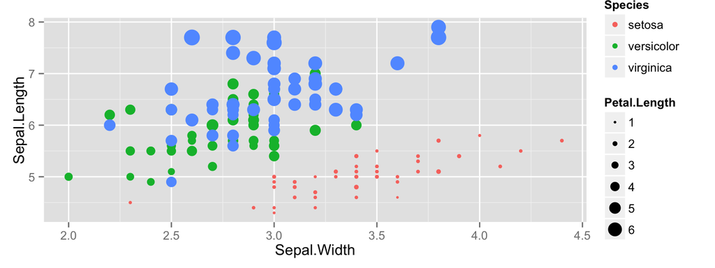

```r
ggplot(iris) + geom_point(aes(x= Sepal.Width, y=Sepal.Length, color=Species, size=Petal.Length))
```

# Using a continuous variable

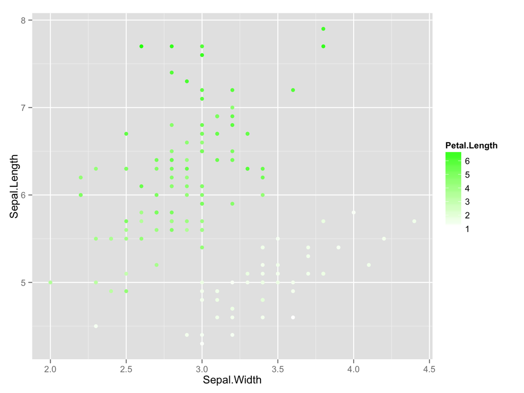

```r
ggplot(iris) + geom_point(aes(x= Sepal.Width, y=Sepal.Length, color=Petal.Length)) +
  scale_color_continuous(low = "white", high = "green")
```

# Other aesthetic attributes: Size

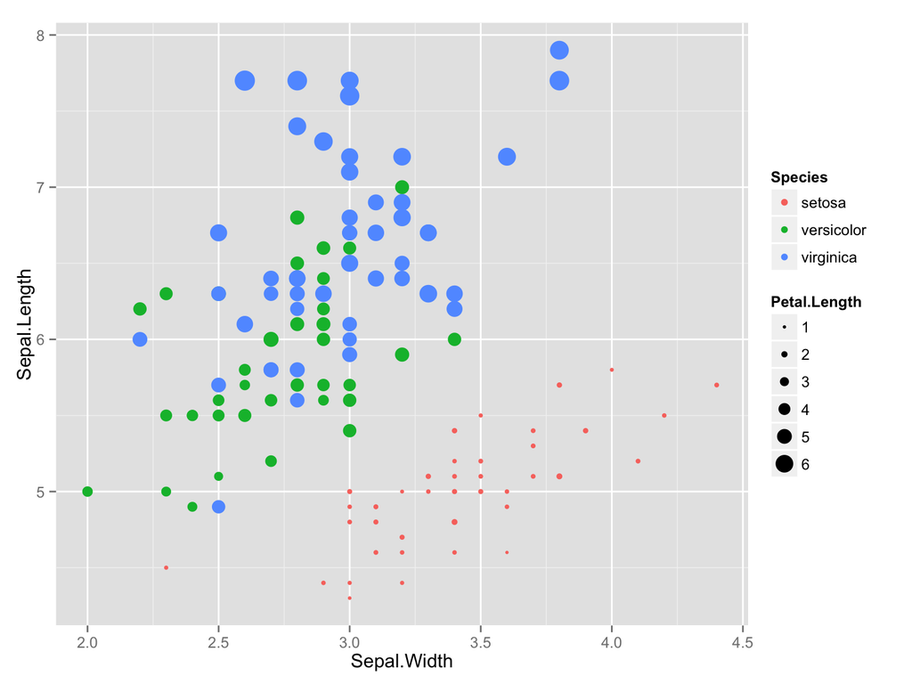

```r
ggplot(iris) + geom_point(aes(x= Sepal.Width, y=Sepal.Length, size=Petal.Length, color=Species))
```